# Character Analysis and Prediction

#### PES University - Banglore

## Data Analytics Project - Class of Prof. SMP

#### Sameer Singh(01FB15ECS259) Sashank M(01FB15ECS268) Shreyas Miraj(01FB15ECS285)

## Introduction

In 2013, students of the Statistics class at Faculty of Social and Economic Sciences(BARTISLAV) UK were asked to invite their friends to participate in this survey.

The data file (responses.csv) consists of 1010 rows and 150 columns (139 integer and 11 categorical). For convenience, the original variable names were shortened in the data file. See the columns.csv file if you want to match the data with the original names. The data contain missing values. The survey was presented to participants in both electronic and written form. The original questionnaire was in Slovak language and was later translated into English. All participants were of Slovakian nationality, aged between 15-30.

The variables can be split into the following groups:

- Music preferences (19 items)
- Movie preferences (12 items)
- Hobbies & interests (32 items)
- Phobias (10 items)
- Health habits (3 items)
- Personality traits, views on life, & opinions (57 items)
- Spending habits (7 items)
- Demographics (10 items)

## Our aim for this project

- Forming unsupervised cluster from the dataset *Whole Dataset* On sub-groups mentioned above
- Building model to predict whether a given person when angry may deal damage to their surroundings
- Building model to predict whether a given person is a smoker

#### Libraries used for the project and the data set read

```r
library(ggplot2)
library(corrplot)
library(NbClust)
library(cluster)
library(caret)
library(ROCR)
library(e1071)
library(class)
library(lubridate)
responses <- read.csv("C:/Users/ThePilot/Documents/PES/CSE_V/responses.csv")
responses_final <- responses
```

### Preprocessing of data

Since the given data not only consists of numerical data but also categorical text we need to convert these to appropriate numerical values representing the same so that analysis and building models are easier

```r
responses$Gender_Numeric = 1
responses$Gender_Numeric[responses$Gender == 'female'] = 0
responses_final$Gender <- responses$Gender_Numeric
responses$Smoking_Numeric = 0
responses$Smoking_Numeric[responses$Smoking == "former smoker"] = 1
responses$Smoking_Numeric[responses$Smoking == "current smoker"] = 2
responses_final$Smoking <- responses$Smoking_Numeric
responses$Drinking_Numeric = 0
responses$Drinking_Numeric[responses$Alcohol == "social drinker"] = 1
responses$Drinking_Numeric[responses$Alcohol == "drink a lot"] = 2
responses_final$Alcohol <- responses$Drinking_Numeric
responses$Handed_Numeric = 0
responses$Handed_Numeric[responses$Left...right.handed == "left handed"] = 1
responses_final$Left...right.handed <- responses$Handed_Numeric
responses$Locality_Numeric = 0
responses$Locality_Numeric[responses$Village...town == "city"] = 1
responses_final$Village...town <- responses$Locality_Numeric
responses$Residence_Numeric = 0
responses$Residence_Numeric[responses$House...block.of.flats == "house/bungalow"] = 1
responses_final$House...block.of.flats <- responses$Residence_Numeric
responses$Only_child_Numeric = 0
responses$Only_child_Numeric[responses$Only.child == "yes"] = 1
responses_final$Only.child <- responses$Only_child_Numeric
responses$Education_Numeric = 0
responses$Education_Numeric[responses$Education == "secondary school"] = 1
responses$Education_Numeric[responses$Education == "college/bachelor degree"] = 2
responses$Education_Numeric[responses$Education == "masters degree"] = 3
responses$Education_Numeric[responses$Education == "doctorate degree"] = 4
responses_final$Education <- responses$Education_Numeric
responses$Punctuality_Numeric = 0
responses$Punctuality_Numeric[responses$Punctuality == "i am always on time"] = 1
responses$Punctuality_Numeric[responses$Punctuality == "i am often early"] = 2
responses_final$Punctuality <- responses$Punctuality_Numeric
responses$Internet_usage_Numeric = 0
responses$Internet_usage_Numeric[responses$Internet.usage == "less than an hour a day"] = 1
responses$Internet_usage_Numeric[responses$Internet.usage == "few hours a day"] = 2
responses$Internet_usage_Numeric[responses$Internet.usage == "most of the day"] = 3
responses_final$Internet.usage <- responses$Internet_usage_Numeric
responses$Lying_Numeric = 0
responses$Lying_Numeric[responses$Lying == "only to avoid hurting someone"] = 1
responses$Lying_Numeric[responses$Lying == "sometimes"] = 2
responses$Lying_Numeric[responses$Lying == "everytime it suits me"] = 3
responses_final$Lying <- responses$Lying_Numeric
responses_final$criminal = 0
responses_final$criminal[responses_final$Criminal.damage > 3] = 1
responses_final$social_drinker = 0
responses_final$social_drinker[responses_final$Alcohol == 1] = 1
responses_final$alcoholic = 0
responses_final$alcoholic[responses_final$Alcohol == 2] = 1
responses_final$smoking_former = 0
responses_final$smoking_former[responses_final$Smoking == 1] = 1
responses_final$smoking_current = 0
responses_final$smoking_current[responses_final$Smoking == 2] = 2
responses_final$smoker = 0
responses_final$smoker[responses_final$Smoking > 0] = 1
```

Since certain values are missing in one or the other column the usual way to go around this problem would be to drop the row containg NA values but since we have 150 cloumns representing different aspects and there being only 1010 rows its not preferable to lose any data as it’ll reduce the data available to train the models.  
Therefore we choose to switch these NA values with the means(as integer) of the respective columns(which is preferable here)

```r
for(i in 1:ncol(responses_final)){
 responses_final[is.na(responses_final[,i]), i] <- as.integer(mean(responses_final[,i], na.rm = TRUE))
}
```

### PCA

Lets try and reduce the number of avalaible columns by running PCA over the responses dataset to see if anything can be reduced at all.

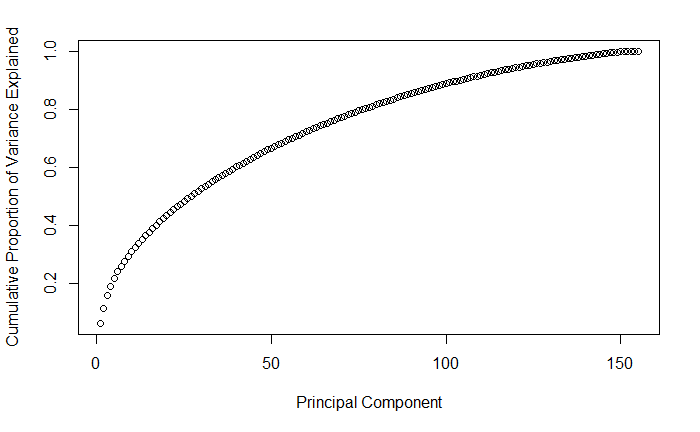

```r
new_frame <- responses_final
new_frame$Criminal.damage=NULL
prin_comp <- prcomp(new_frame, scale. = TRUE)
std_dev <- prin_comp$sdev
pr_var <- std_dev^2
prop_varex <- pr_var/sum(pr_var)
plot(cumsum(prop_varex), xlab = "Principal Component",
     ylab = "Cumulative Proportion of Variance Explained",
     type = "b")
```

As we can see that the Explained variance for PC never reaches 1 before 150, we cannot reduce any columns from the dataset responses_final

### Correlation among all the 150vs150 columns

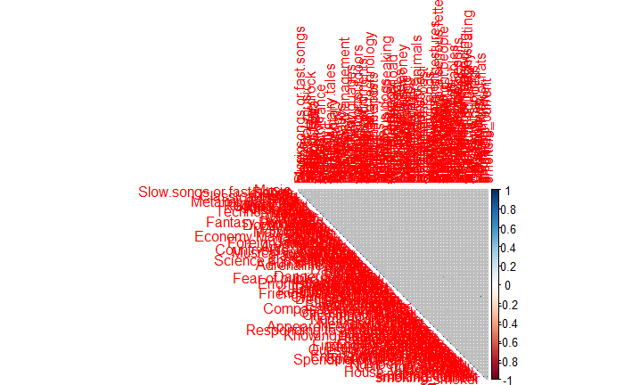

```r
options(scipen = 999)
cor_plot = cor(responses_final)
corrplot(cor_plot, type = "upper")
```

### K-Means Clustering

```
NbClust give the most voted best number of clusters
```

#### Whole Dataset

[output not shown]

```
*** : The Hubert index is a graphical method of determining the number of clusters.
                In the plot of Hubert index, we seek a significant knee that corresponds to a
                significant increase of the value of the measure i.e the significant peak in Hubert
                index second differences plot.
```

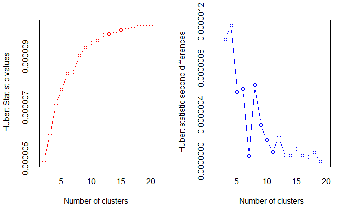

```
*** : The D index is a graphical method of determining the number of clusters.
                In the plot of D index, we seek a significant knee (the significant peak in Dindex
                second differences plot) that corresponds to a significant increase of the value of
                the measure.

* Among all indices:
* 13 proposed 2 as the best number of clusters
* 6 proposed 3 as the best number of clusters
* 1 proposed 4 as the best number of clusters
* 2 proposed 8 as the best number of clusters
* 1 proposed 20 as the best number of clusters

                   ***** Conclusion *****

* According to the majority rule, the best number of clusters is  2
```

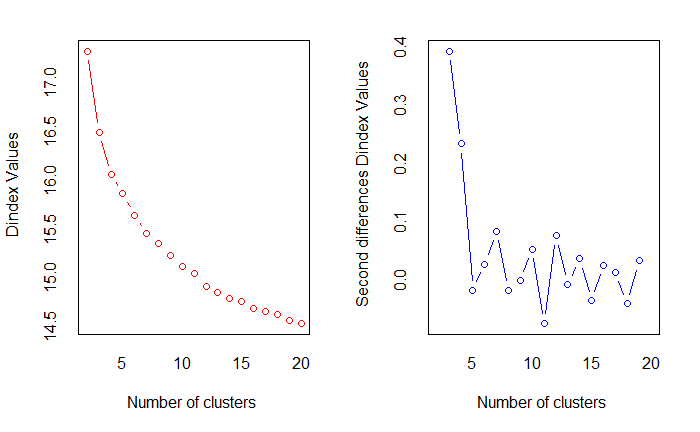

```r
k_means <- NbClust(responses_final[,1:150],min.nc = 2, max.nc = 20, method = "kmeans")
```

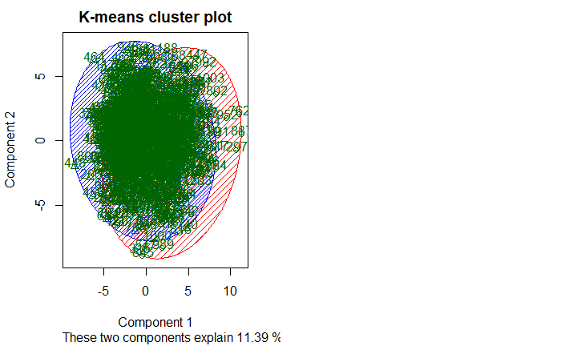

```r
set.seed(100)
km_mo <- kmeans(responses_final,2)
clusplot(responses_final, km_mo$cluster,color=TRUE, shade=TRUE,
         labels=3, lines=0, main="K-means cluster plot")
```

```
We could not bring about any conclusive traits for the two clusters formed by K-means(also min ncluster is set to 2)
```

### Music Preferences

```
*** : The Hubert index is a graphical method of determining the number of clusters.
                In the plot of Hubert index, we seek a significant knee that corresponds to a
                significant increase of the value of the measure i.e the significant peak in Hubert
                index second differences plot.
```

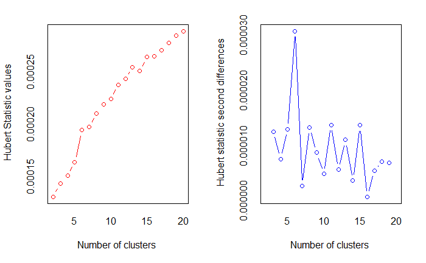

```
*** : The D index is a graphical method of determining the number of clusters.
                In the plot of D index, we seek a significant knee (the significant peak in Dindex
                second differences plot) that corresponds to a significant increase of the value of
                the measure.

* Among all indices:
* 8 proposed 2 as the best number of clusters
* 10 proposed 3 as the best number of clusters
* 1 proposed 11 as the best number of clusters
* 2 proposed 15 as the best number of clusters
* 1 proposed 19 as the best number of clusters
* 1 proposed 20 as the best number of clusters

                   ***** Conclusion *****

* According to the majority rule, the best number of clusters is  3
```

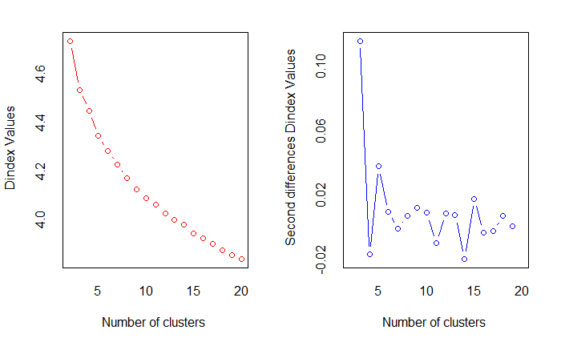

```r
traits <- NbClust(responses_final[,1:19],min.nc = 2,max.nc = 20,method = "kmeans")
```

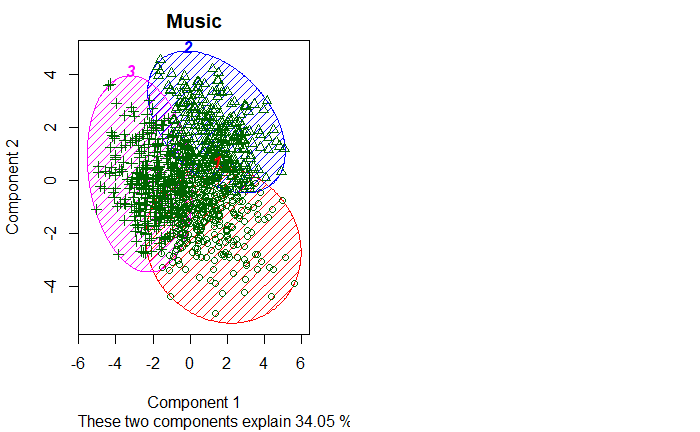

```r
set.seed(100)
trait_mat <- kmeans(responses_final[,1:19],3)
clusplot(responses_final[,1:19],trait_mat$cluster, color=TRUE,shade=TRUE,labels = 4, lines = 0, main = "Music")
```

```r
aggregate(responses_final[,1:19], by=list(cluster=trait_mat$cluster), mean)
```

| cluster | Music | Slow.songs.or.fast.songs | Dance | Folk | Country | Classical.music | Musical | Pop | Rock | Metal.or.Hardrock | Punk | Hiphop..Rap | Reggae..Ska | Swing..Jazz | Rock.n.roll | Alternative | Latino | Techno..Trance | Opera |
| --- | --- | --- | --- | --- | --- | --- | --- | --- | --- | --- | --- | --- | --- | --- | --- | --- | --- | --- | --- |
| 1 | 4.749271 | 3.288630 | 3.612245 | 2.822157 | 2.513120 | 3.553936 | 3.565598 | 3.892128 | 3.816327 | 2.052478 | 2.309038 | 3.247813 | 3.157434 | 3.478134 | 3.603499 | 2.967930 | 3.801749 | 2.644315 | 2.731778 |
| 2 | 4.808442 | 3.295455 | 2.269481 | 2.237013 | 2.116883 | 3.233766 | 2.561688 | 2.766234 | 4.616883 | 3.616883 | 3.451299 | 2.064935 | 2.818182 | 2.909091 | 3.704545 | 3.694805 | 2.194805 | 1.730519 | 2.207792 |
| 3 | 4.643454 | 3.392758 | 3.359331 | 1.818942 | 1.754875 | 2.128134 | 2.161560 | 3.671309 | 2.963788 | 1.576602 | 1.732591 | 3.303621 | 2.342618 | 1.933148 | 2.214485 | 1.935933 | 2.462396 | 2.562674 | 1.515320 |

### Movie Preferences

```
*** : The Hubert index is a graphical method of determining the number of clusters.
                In the plot of Hubert index, we seek a significant knee that corresponds to a
                significant increase of the value of the measure i.e the significant peak in Hubert
                index second differences plot.
```

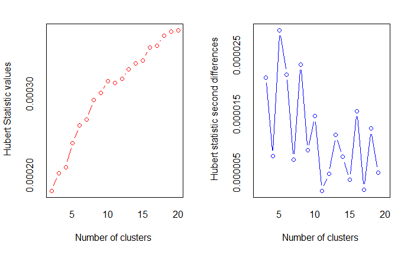

```
*** : The D index is a graphical method of determining the number of clusters.
                In the plot of D index, we seek a significant knee (the significant peak in Dindex
                second differences plot) that corresponds to a significant increase of the value of
                the measure.

* Among all indices:
* 7 proposed 2 as the best number of clusters
* 11 proposed 3 as the best number of clusters
* 1 proposed 9 as the best number of clusters
* 1 proposed 16 as the best number of clusters
* 1 proposed 19 as the best number of clusters
* 2 proposed 20 as the best number of clusters

                   ***** Conclusion *****

* According to the majority rule, the best number of clusters is  3
```

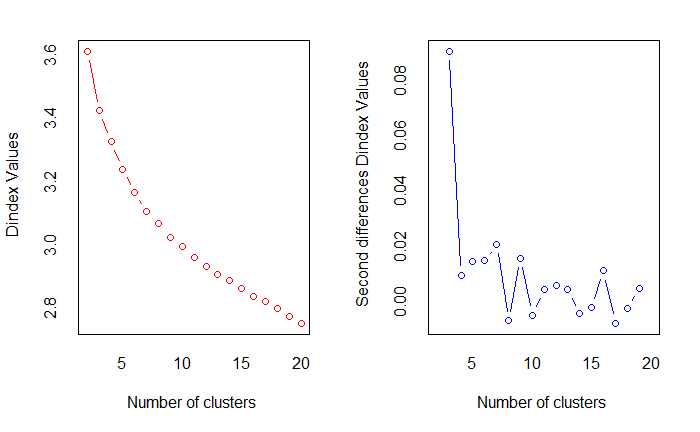

```r
traits <- NbClust(responses_final[,20:31],min.nc = 2,max.nc = 20,method = "kmeans")
```

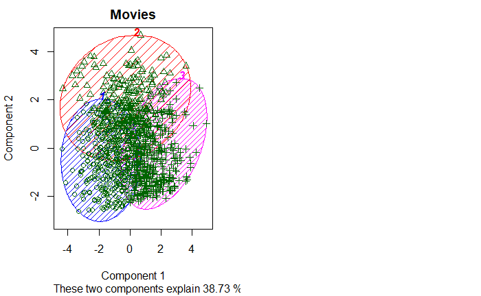

```r
set.seed(100)
trait_mat <- kmeans(responses_final[,20:31],3)
clusplot(responses_final[,20:31],trait_mat$cluster, color=TRUE,shade=TRUE,labels = 4, lines = 0, main = "Movies")
```

```r
aggregate(responses_final[,20:31], by=list(cluster=trait_mat$cluster), mean)
```

| cluster | Movies | Horror | Thriller | Comedy | Romantic | Sci.fi | War | Fantasy.Fairy.tales | Animated | Documentary | Western | Action |
| --- | --- | --- | --- | --- | --- | --- | --- | --- | --- | --- | --- | --- |
| 1 | 4.791667 | 3.425595 | 4.032738 | 4.672619 | 3.386905 | 4.074405 | 4.059524 | 4.068452 | 4.303571 | 4.074405 | 2.755952 | 4.333333 |
| 2 | 4.439446 | 2.896194 | 3.491349 | 4.134948 | 2.844291 | 2.944637 | 3.169550 | 2.480969 | 2.432526 | 3.359862 | 2.089965 | 3.474048 |
| 3 | 4.579221 | 2.161039 | 2.735065 | 4.605195 | 4.059740 | 2.400000 | 2.355844 | 4.418182 | 4.350649 | 3.467532 | 1.602597 | 2.885714 |

#### Hobbies & Interests

```
*** : The Hubert index is a graphical method of determining the number of clusters.
                In the plot of Hubert index, we seek a significant knee that corresponds to a
                significant increase of the value of the measure i.e the significant peak in Hubert
                index second differences plot.
```

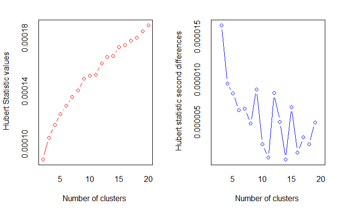

```
*** : The D index is a graphical method of determining the number of clusters.
                In the plot of D index, we seek a significant knee (the significant peak in Dindex
                second differences plot) that corresponds to a significant increase of the value of
                the measure.

* Among all indices:
* 7 proposed 2 as the best number of clusters
* 5 proposed 3 as the best number of clusters
* 5 proposed 4 as the best number of clusters
* 1 proposed 8 as the best number of clusters
* 2 proposed 10 as the best number of clusters
* 1 proposed 17 as the best number of clusters
* 2 proposed 20 as the best number of clusters

                   ***** Conclusion *****

* According to the majority rule, the best number of clusters is  2
```

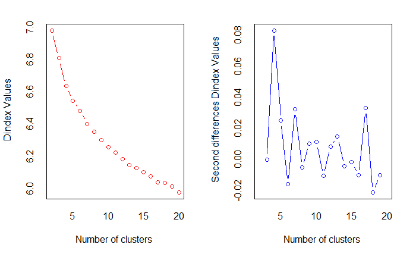

```r
traits <- NbClust(responses_final[,32:63],min.nc = 2,max.nc = 20,method = "kmeans")
```

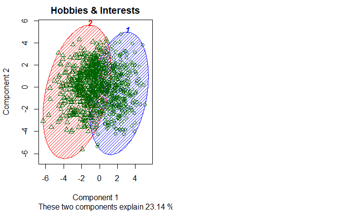

```r
set.seed(100)
trait_mat <- kmeans(responses_final[,32:63],2)
clusplot(responses_final[,32:63],trait_mat$cluster, color=TRUE,shade=TRUE,labels = 4, lines = 0, main = "Hobbies & Interests")
```

```r
aggregate(responses_final[,32:63], by=list(cluster=trait_mat$cluster), mean)
```

| cluster | History | Psychology | Politics | Mathematics | Physics | Internet | PC | Economy.Management | Biology | Chemistry | Reading | Geography | Foreign.languages | Medicine | Law | Cars | Art.exhibitions | Religion | Countryside..outdoors | Dancing | Musical.instruments | Writing | Passive.sport | Active.sport | Gardening | Celebrities | Shopping | Science.and.technology | Theatre | … |
| --- | --- | --- | --- | --- | --- | --- | --- | --- | --- | --- | --- | --- | --- | --- | --- | --- | --- | --- | --- | --- | --- | --- | --- | --- | --- | --- | --- | --- | --- | --- |
| 1 | 2.835443 | 2.613924 | 2.424051 | 2.261603 | 1.888186 | 4.312236 | 3.400844 | 2.789030 | 1.959916 | 1.580169 | 2.362869 | 2.822785 | 3.413502 | 1.795359 | 2.065401 | 2.962025 | 1.827004 | 1.683544 | 3.286920 | 1.829114 | 1.687764 | 1.364979 | 3.533755 | 3.181435 | 1.531646 | 2.341772 | 3.105485 | 3.086498 | 2.329114 | … |
| 2 | 3.535448 | 3.600746 | 2.746269 | 2.397388 | 2.220149 | 4.054104 | 2.901119 | 2.509328 | 3.281716 | 2.679104 | 3.861940 | 3.311567 | 4.093284 | 3.149254 | 2.425373 | 2.438433 | 3.257463 | 2.792910 | 4.031716 | 3.018657 | 2.886194 | 2.365672 | 3.248134 | 3.386194 | 2.227612 | 2.378731 | 3.427239 | 3.361940 | 3.639925 | … |

#### Phobias

```
did not converge in 10 iterationsdid not converge in 10 iterationsdid not converge in 10 iterations
```

```
*** : The Hubert index is a graphical method of determining the number of clusters.
                In the plot of Hubert index, we seek a significant knee that corresponds to a
                significant increase of the value of the measure i.e the significant peak in Hubert
                index second differences plot.
```

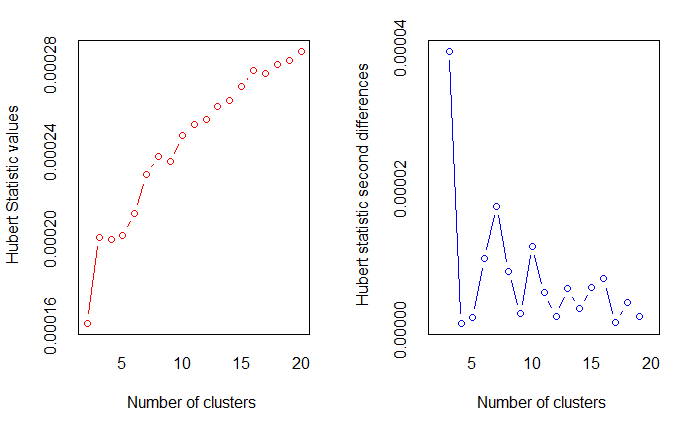

```
*** : The D index is a graphical method of determining the number of clusters.
                In the plot of D index, we seek a significant knee (the significant peak in Dindex
                second differences plot) that corresponds to a significant increase of the value of
                the measure.

* Among all indices:
* 13 proposed 2 as the best number of clusters
* 3 proposed 3 as the best number of clusters
* 5 proposed 4 as the best number of clusters
* 2 proposed 7 as the best number of clusters
* 1 proposed 20 as the best number of clusters

                   ***** Conclusion *****

* According to the majority rule, the best number of clusters is  2
```

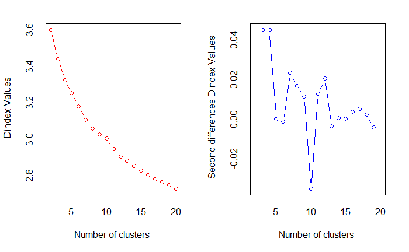

```r
traits <- NbClust(responses_final[,64:73],min.nc = 2,max.nc = 20,method = "kmeans")
```

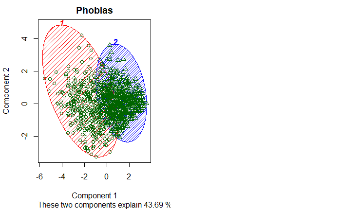

```r
set.seed(100)
trait_mat <- kmeans(responses_final[,64:73],2)
clusplot(responses_final[,64:73],trait_mat$cluster, color=TRUE,shade=TRUE,labels = 4, lines = 0, main = "Phobias")
```

```r
aggregate(responses_final[,64:73], by=list(cluster=trait_mat$cluster), mean)
```

| cluster | Flying | Storm | Darkness | Heights | Spiders | Snakes | Rats | Ageing | Dangerous.dogs | Fear.of.public.speaking |
| --- | --- | --- | --- | --- | --- | --- | --- | --- | --- | --- |
| 1 | 2.482030 | 2.530655 | 2.832981 | 3.073996 | 3.723044 | 4.122622 | 3.359408 | 3.042283 | 3.723044 | 3.097252 |
| 2 | 1.690875 | 1.480447 | 1.737430 | 2.208566 | 2.027933 | 2.063315 | 1.569832 | 2.173184 | 2.443203 | 2.543762 |

#### Over Personality, views on life and opinions category of responses

```
*** : The Hubert index is a graphical method of determining the number of clusters.
                In the plot of Hubert index, we seek a significant knee that corresponds to a
                significant increase of the value of the measure i.e the significant peak in Hubert
                index second differences plot.
```

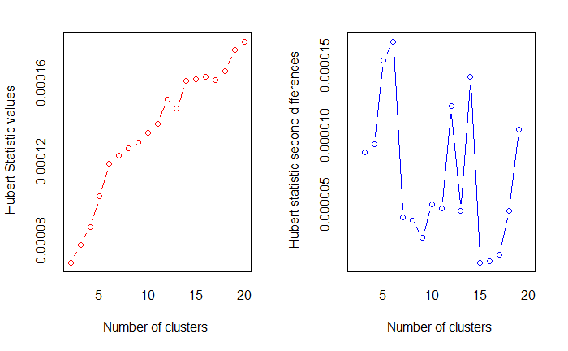

```
*** : The D index is a graphical method of determining the number of clusters.
                In the plot of D index, we seek a significant knee (the significant peak in Dindex
                second differences plot) that corresponds to a significant increase of the value of
                the measure.

* Among all indices:
* 8 proposed 2 as the best number of clusters
* 9 proposed 3 as the best number of clusters
* 2 proposed 5 as the best number of clusters
* 2 proposed 18 as the best number of clusters
* 1 proposed 19 as the best number of clusters
* 1 proposed 20 as the best number of clusters

                   ***** Conclusion *****

* According to the majority rule, the best number of clusters is  3
```

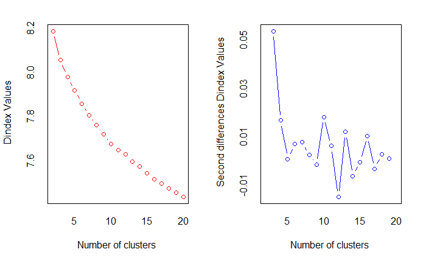

```r
  traits <- NbClust(responses_final[,77:133],min.nc = 2,max.nc = 20,method = "kmeans")
```

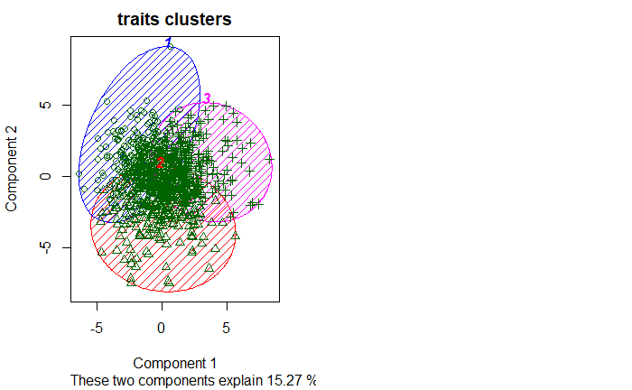

```r
set.seed(50)
trait_mat <- kmeans(responses_final[,77:133],3)
clusplot(responses_final[,77:133],trait_mat$cluster, color=TRUE,shade=TRUE,labels = 4, lines = 0, main = "traits clusters")
```

```r
aggregate(responses_final[,77:133], by=list(cluster=trait_mat$cluster), mean)
```

| cluster | Daily.events | Prioritising.workload | Writing.notes | Workaholism | Thinking.ahead | Final.judgement | Reliability | Keeping.promises | Loss.of.interest | Friends.versus.money | Funniness | Fake | Criminal.damage | Decision.making | Elections | Self.criticism | Judgment.calls | Hypochondria | Empathy | Eating.to.survive | Giving | Compassion.to.animals | Borrowed.stuff | Loneliness | Cheating.in.school | Health | Changing.the.past | God | Dreams | … |
| --- | --- | --- | --- | --- | --- | --- | --- | --- | --- | --- | --- | --- | --- | --- | --- | --- | --- | --- | --- | --- | --- | --- | --- | --- | --- | --- | --- | --- | --- | --- |
| 1 | 3.266667 | 3.212821 | 3.735897 | 3.600000 | 3.758974 | 3.079487 | 4.251282 | 4.276923 | 2.548718 | 4.102564 | 3.333333 | 1.825641 | 2.161538 | 3.276923 | 4.041026 | 3.674359 | 4.117949 | 1.774359 | 4.197436 | 2.120513 | 3.461538 | 4.158974 | 4.307692 | 2.656410 | 3.405128 | 3.389744 | 2.646154 | 3.838462 | 3.384615 | … |
| 2 | 2.897196 | 2.077882 | 2.133956 | 2.292835 | 2.887850 | 2.065421 | 3.526480 | 3.738318 | 2.775701 | 3.629283 | 3.339564 | 2.099688 | 2.834891 | 2.619938 | 2.981308 | 3.028037 | 3.881620 | 1.660436 | 3.479751 | 2.118380 | 2.619938 | 3.700935 | 3.591900 | 2.523364 | 4.227414 | 2.890966 | 2.694704 | 2.844237 | 3.342679 | … |
| 3 | 3.013378 | 2.505017 | 3.250836 | 2.946488 | 3.525084 | 2.698997 | 3.692308 | 3.872910 | 2.836120 | 3.501672 | 3.187291 | 2.561873 | 2.919732 | 3.712375 | 3.060201 | 4.036789 | 3.916388 | 2.351171 | 3.809365 | 2.488294 | 2.705686 | 3.993311 | 4.096990 | 3.575251 | 3.658863 | 3.454849 | 3.622074 | 3.093645 | 3.133779 | … |

### Correlation(damage makers, smokers, alcoholics)

#### Utility function to get correlation of one column with all other columns

```r
corr_matrix <- function(y,df){
  x = c()
  for(i in c(1:150)){
    x <- c(x,cor(df[,i],df[,y]))
  }
  names <- c()
  corr <- c()
  for(i in c(1:150)){
      names <- c(names,names(df)[i])
      corr <- c(corr,x[i])
  }
  result <- data.frame(names,corr)
  return(result)
}
rmse <- function(error){
  sqrt(mean(error^2))
}
```

### Corr for people who damage stuff around them when angry

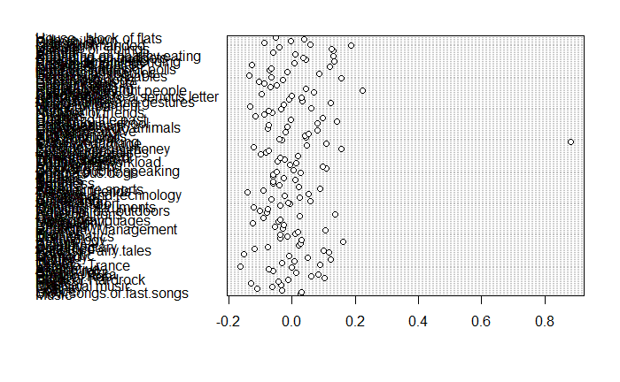

```r
corr_crime_others = corr_matrix("criminal",responses_final)
dotchart(corr_crime_others$corr,labels = corr_crime_others$names)
```

### Corr for people who are alcoholics

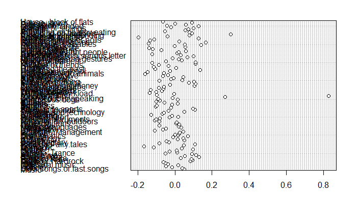

```r
alcoholic_corr_matrix = corr_matrix("alcoholic",responses_final)
dotchart(alcoholic_corr_matrix$corr,labels = alcoholic_corr_matrix$names)
```

### Corr for people who are social drinkers

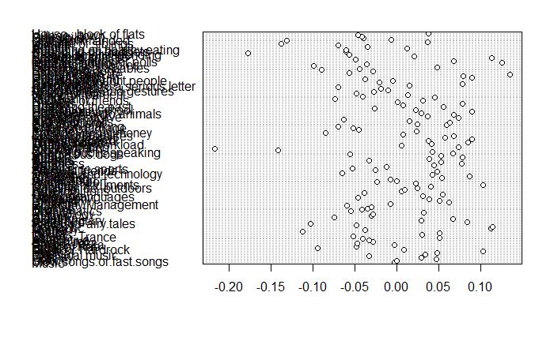

```r
social_corr_matrix = corr_matrix("social_drinker",responses_final)
dotchart(social_corr_matrix$corr,labels = social_corr_matrix$names)
```

### Corr for people who are smokers

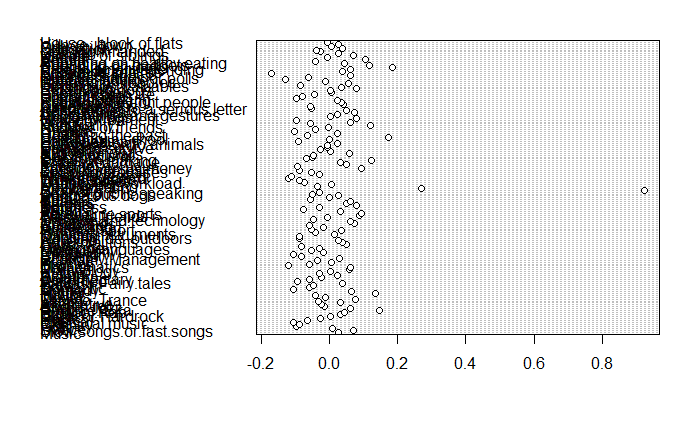

```r
smoker_corr_matrix = corr_matrix("smoker",responses_final)
dotchart(smoker_corr_matrix$corr, labels = smoker_corr_matrix$names)
```

## Prediction Models

### Model for predicting damage makers when angry

```r
df <- responses_final[,c(1:151)]
set.seed(120)
intermediate <- createDataPartition(y = df$criminal, p=0.7, list=FALSE)
train.df <- df[intermediate,]
test.df <- df[-intermediate,]
train_dmg <- subset(train.df,select = -c(Criminal.damage))
test_dmg = subset(test.df,select = -c(Criminal.damage))
```

```
Splitting data into test and train
```

### Logistic Regression

```r
model <- glm(criminal~.,family=binomial(link='logit'),data=train_dmg)
summary(model)
```

```
Call:
glm(formula = criminal ~ ., family = binomial(link = "logit"),
    data = train_dmg)

Deviance Residuals:
    Min       1Q   Median       3Q      Max
-2.7789  -0.6042  -0.2603   0.3831   2.9110

Coefficients:
                                 Estimate Std. Error z value Pr(>|z|)
(Intercept)                    -3.8260034  3.9823541  -0.961  0.33668
Music                           0.5270097  0.2461164   2.141  0.03225 *
Slow.songs.or.fast.songs        0.2494808  0.1706278   1.462  0.14370
Dance                           0.0517233  0.1490103   0.347  0.72851
Folk                           -0.2001503  0.1487745  -1.345  0.17852
Country                         0.0473969  0.1543562   0.307  0.75880
Classical.music                 0.2437149  0.1516738   1.607  0.10809
Musical                        -0.0190421  0.1395452  -0.136  0.89146
Pop                             0.0803039  0.1463295   0.549  0.58315
Rock                           -0.0319860  0.1624909  -0.197  0.84395
Metal.or.Hardrock               0.1558329  0.1292485   1.206  0.22794
Punk                            0.1636377  0.1443559   1.134  0.25697
Hiphop..Rap                    -0.0224405  0.1244427  -0.180  0.85690
Reggae..Ska                     0.0862000  0.1334685   0.646  0.51838
Swing..Jazz                     0.0971922  0.1398965   0.695  0.48722
Rock.n.roll                    -0.3554079  0.1379565  -2.576  0.00999 **
Alternative                     0.1738533  0.1204225   1.444  0.14883
Latino                         -0.1860844  0.1316524  -1.413  0.15752
Techno..Trance                 -0.0548052  0.1116329  -0.491  0.62347
Opera                           0.2214010  0.1665875   1.329  0.18384
Movies                          0.1453326  0.2162086   0.672  0.50146
Horror                          0.1883788  0.1144467   1.646  0.09976 .
Thriller                       -0.2667924  0.1421514  -1.877  0.06054 .
Comedy                          0.1213893  0.1992514   0.609  0.54237
Romantic                       -0.1051703  0.1414616  -0.743  0.45721
Sci.fi                          0.0695603  0.1174871   0.592  0.55381
War                            -0.0279085  0.1212512  -0.230  0.81796
Fantasy.Fairy.tales            -0.3551400  0.1723117  -2.061  0.03930 *
Animated                        0.0913133  0.1606941   0.568  0.56987
Documentary                     0.0173649  0.1408522   0.123  0.90188
```

[output cut: 115 more lines]

```
Left...right.handed             0.3479600  0.4088214   0.851  0.39470
Education                      -0.1776059  0.2289123  -0.776  0.43783
Only.child                      0.0652821  0.3459943   0.189  0.85034
Village...town                 -0.0390447  0.3605397  -0.108  0.91376
House...block.of.flats         -0.2130242  0.3335332  -0.639  0.52302
---
Signif. codes:  0 *** 0.001 ** 0.01 * 0.05 . 0.1   1

(Dispersion parameter for binomial family taken to be 1)

    Null deviance: 847.78  on 706  degrees of freedom
Residual deviance: 530.40  on 557  degrees of freedom
AIC: 830.4

Number of Fisher Scoring iterations: 6
```

```r
#model performance#
p <- predict(model,newdata = subset(test_dmg, select = -c(criminal)))
rmse_p <- RMSE(p,test_dmg$criminal)
p <- ifelse(p > 0.5,1,0)
misClassificationError <- mean(p != test_dmg$criminal)
print(paste('Accuracy',1-misClassificationError))
```

```
[1] "Accuracy 0.666666666666667"
```

```r
#Rock.n.roll, Empathy, Getting.angry, Small...big.dogs, Gender, Entertainment.spending, Getting.up, Children, Waiting, Number.of.friends, Dreams, Cheating.in.school, Self.criticism, Smoking, Snakes, Celebrities, Reading, Politics, Action, Fantasy.Fairy.tales, Music
#gave p confidence values below or equal 0.01
#now running this on the reduced data set
train_dmg_r1 <- subset(train_dmg, select = c(Rock.n.roll, Empathy, Getting.angry, Small...big.dogs, Gender, Entertainment.spending, Getting.up, Children, Waiting, Number.of.friends, Dreams, Cheating.in.school, Self.criticism, Smoking, Snakes, Celebrities, Reading, Politics, Action, Fantasy.Fairy.tales, Music, criminal))
model1 <- glm(criminal~.,family=binomial(link='logit'),data=train_dmg_r1)
summary(model1)
```

```
Call:
glm(formula = criminal ~ ., family = binomial(link = "logit"),
    data = train_dmg_r1)

Deviance Residuals:
    Min       1Q   Median       3Q      Max
-2.2066  -0.7555  -0.4605   0.7056   2.8130

Coefficients:
                       Estimate Std. Error z value        Pr(>|z|)
(Intercept)            -4.59976    1.27566  -3.606        0.000311 ***
Rock.n.roll            -0.11758    0.08225  -1.430        0.152833
Empathy                 0.20447    0.09201   2.222        0.026272 *
Getting.angry           0.60762    0.09291   6.540 0.0000000000617 ***
Small...big.dogs        0.29406    0.08422   3.492        0.000480 ***
Gender                  1.07075    0.25238   4.243 0.0000220968070 ***
Entertainment.spending -0.12739    0.08968  -1.420        0.155491
Getting.up              0.08755    0.07708   1.136        0.256047
Children                0.05365    0.09339   0.574        0.565666
Waiting                -0.27201    0.10291  -2.643        0.008215 **
Number.of.friends      -0.29535    0.10129  -2.916        0.003549 **
Dreams                 -0.29991    0.15437  -1.943        0.052047 .
Cheating.in.school      0.17208    0.08564   2.009        0.044498 *
Self.criticism          0.12008    0.08738   1.374        0.169400
Smoking                 0.29045    0.12483   2.327        0.019981 *
Snakes                 -0.16891    0.07104  -2.378        0.017417 *
Celebrities             0.13664    0.08377   1.631        0.102853
Reading                -0.11871    0.07363  -1.612        0.106905
Politics               -0.16684    0.07937  -2.102        0.035544 *
Action                  0.28033    0.09125   3.072        0.002126 **
Fantasy.Fairy.tales    -0.17722    0.08981  -1.973        0.048463 *
Music                   0.39612    0.16991   2.331        0.019732 *
---
Signif. codes:  0 *** 0.001 ** 0.01 * 0.05 . 0.1   1

(Dispersion parameter for binomial family taken to be 1)

    Null deviance: 847.78  on 706  degrees of freedom
Residual deviance: 670.70  on 685  degrees of freedom
AIC: 714.7

Number of Fisher Scoring iterations: 5
```

```r
#model1 performance
p1 <- predict(model1,newdata = subset(test_dmg, select = -c(criminal)))
rmse_lr <- RMSE(p1,test_dmg$criminal)
print(paste("Model: ",rmse_p))
```

```
[1] "Model:  2.97798697565438"
```

```r
print(paste("Model1: ", rmse_lr))
```

```
[1] "Model1:  2.0649661690911"
```

We can see that the second model reduced variables gave a better rmse score and hence we choose that one with rmse score of 2.064

### SVM

```r
model_svm <- svm(criminal~.,train_dmg)
pred_svm <- predict(model_svm, train_dmg)
svm1_rmse <- RMSE(pred_svm,train_dmg$criminal)
svm1_rmse
```

```
[1] 0.2376436
```

```r
tuneResult <- tune(svm, criminal~.,data = train_dmg, ranges = list(epsilon = seq(0,1,0.1),cost = 2^(2:9)))
print(tuneResult)
```

```
Parameter tuning of svm:

- sampling method: 10-fold cross validation

- best parameters:
 epsilon cost
     0.2    4

- best performance: 0.1846116
```

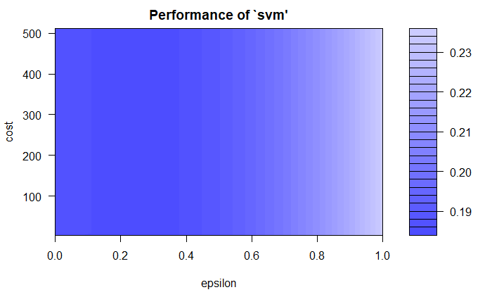

```r
plot(tuneResult)
```

```r
tuneResult <- tune(svm,criminal~.,data = train_dmg,ranges = list(epsilon = seq(0,0.2,0.01), cost = 2^(2:9)))
print(tuneResult)
```

```
Parameter tuning of svm:

- sampling method: 10-fold cross validation

- best parameters:
 epsilon cost
     0.2    4

- best performance: 0.1807937
```

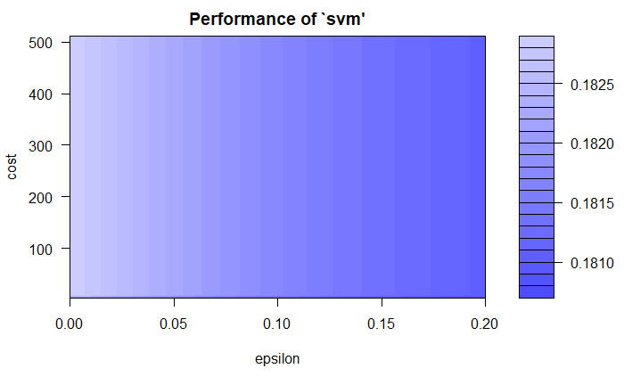

```r
plot(tuneResult)
```

```r
#tuned_svm
tuned_svm <- svm(criminal~.,train_dmg, epsilon = 0.2, cost = 4)
pred_tune_svm <- predict(tuned_svm,subset(train_dmg))
rmse_tuned_svm <- RMSE(pred_tune_svm, train_dmg$criminal)
print(paste("svm_train_rmse: ",rmse_tuned_svm))
```

```
[1] "svm_train_rmse:  0.0884501143202854"
```

```r
pred_tune_test <- predict(tuned_svm,test_dmg)
rmse_test_tuned_svm <- RMSE(pred_tune_test,test_dmg$criminal)
print(paste("svm_test_rmse: ",rmse_test_tuned_svm))
```

```
[1] "svm_test_rmse:  0.450801334664192"
```

# Damage dealing prediction when angry models comparision

[output not shown]

### Model for smoker prediction

```r
#train and test data
dfs <- subset(responses_final, select = -c(151,152,153,154,155))
set.seed(120)
## 70% of the sample size for training data
intermediate <- createDataPartition(y = dfs$smoker, p=0.7, list=FALSE)
train.dfs <- dfs[intermediate,]
test.dfs <- dfs[-intermediate,]
train_smoke <- subset(train.dfs,select = -c(Smoking))
test_smoke <- subset(test.dfs,select = -c(Smoking))
```

```
Creating test and train dataset with 30-70
```

### Logistic Regression

```r
#######################
# Logistic Regression #
#######################
model_lr_smoker <- glm(smoker~.,family=binomial(link='logit'),data=train_smoke)
summary(model_lr_smoker)
```

```
Call:
glm(formula = smoker ~ ., family = binomial(link = "logit"),
    data = train_smoke)

Deviance Residuals:
    Min       1Q   Median       3Q      Max
-3.1848  -0.6856  -0.2703   0.6192   3.0057

Coefficients:
                                Estimate Std. Error z value   Pr(>|z|)
(Intercept)                    -0.410353   4.013442  -0.102   0.918563
Music                           0.112224   0.193348   0.580   0.561627
Slow.songs.or.fast.songs        0.139164   0.159493   0.873   0.382916
Dance                          -0.229013   0.135729  -1.687   0.091550 .
Folk                           -0.192916   0.132980  -1.451   0.146860
Country                        -0.059933   0.139295  -0.430   0.667008
Classical.music                -0.330810   0.139449  -2.372   0.017679 *
Musical                        -0.230133   0.124591  -1.847   0.064731 .
Pop                             0.098564   0.132359   0.745   0.456470
Rock                           -0.050983   0.144888  -0.352   0.724928
Metal.or.Hardrock               0.173337   0.126095   1.375   0.169238
Punk                            0.084161   0.130618   0.644   0.519364
Hiphop..Rap                     0.441166   0.110946   3.976 0.00006997 ***
Reggae..Ska                    -0.241324   0.121412  -1.988   0.046850 *
Swing..Jazz                     0.208787   0.126488   1.651   0.098810 .
Rock.n.roll                    -0.095185   0.127813  -0.745   0.456442
Alternative                    -0.039332   0.109677  -0.359   0.719881
Latino                          0.060890   0.116897   0.521   0.602447
Techno..Trance                  0.175460   0.107992   1.625   0.104216
Opera                           0.238428   0.145200   1.642   0.100576
Movies                         -0.344708   0.204174  -1.688   0.091354 .
Horror                          0.163893   0.102203   1.604   0.108803
Thriller                       -0.017092   0.130824  -0.131   0.896052
Comedy                         -0.451252   0.187670  -2.404   0.016195 *
Romantic                        0.073322   0.135567   0.541   0.588610
Sci.fi                          0.028102   0.108737   0.258   0.796065
War                             0.084478   0.115927   0.729   0.466171
Fantasy.Fairy.tales            -0.054307   0.161389  -0.336   0.736495
Animated                       -0.138853   0.150259  -0.924   0.355437
Documentary                     0.200011   0.129318   1.547   0.121947
```

[output cut: 115 more lines]

```
Left...right.handed            -0.022448   0.402454  -0.056   0.955518
Education                      -0.108991   0.213678  -0.510   0.610002
Only.child                      0.014947   0.311338   0.048   0.961710
Village...town                 -0.165467   0.322892  -0.512   0.608334
House...block.of.flats          0.297863   0.306634   0.971   0.331352
---
Signif. codes:  0 *** 0.001 ** 0.01 * 0.05 . 0.1   1

(Dispersion parameter for binomial family taken to be 1)

    Null deviance: 939.32  on 706  degrees of freedom
Residual deviance: 601.90  on 557  degrees of freedom
AIC: 901.9

Number of Fisher Scoring iterations: 6
```

```r
#anova(model_lr_smoker,test = "Chisq")
#model performance#
p <- predict(model_lr_smoker,newdata = subset(test_smoke, select = -c(smoker)))
rmse_smoke_lr <- RMSE(p,test_smoke$smoker)
print(paste("lr_rmse: ",rmse_smoke_lr))
```

```
[1] "lr_rmse:  2.71642224625346"
```

### KNN model

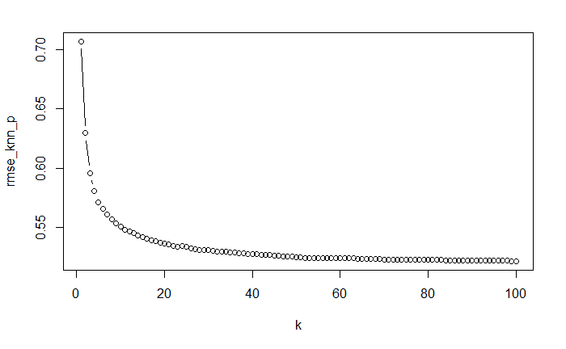

```r
#######
# KNN #
#######
rmse_knn_p <- rep(0, 100)
k <- 1:100
for(x in k){
  knn_smoke <- knn3(smoker~., data = train_smoke, k = x)
  pred_knn <- predict(knn_smoke,train_smoke)
  rmse_knn_p[x] <- RMSE(pred_knn, train_smoke$smoker)
}
plot(k, rmse_knn_p, type = 'b')
```

```r
#around k = 50 the decrease in rmse is very low so we can choose k = 50 for the model
knn_smoke <- knn3(smoker~., data = train_smoke, k = 50)
pred_knn <- predict(knn_smoke,train_smoke)
rmse_knn <- RMSE(pred_knn, train_smoke$smoker)
rmse_knn
```

```
[1] 0.5249724
```

```r
#giving us the error of 0.5249724
pred_knn_test <- predict(knn_smoke,test_smoke)
rmse_knn_test <- RMSE(pred_knn_test, test_smoke$smoker)
rmse_knn_test
```

```
[1] 0.5283913
```

```r
#error for test is 0.5283913
```

### SVM MODEL

```r
#####
#SVM#
#####
model_svm_smoke <- svm(smoker~.,train_smoke)
pred_svm_smoke <- predict(model_svm_smoke, train_smoke)
svm1_rmse_smoke <- RMSE(pred_svm_smoke,train_smoke$smoker)
print(paste("untuned_svm_rmse: ",svm1_rmse_smoke))
```

```
[1] "untuned_svm_rmse:  0.215398553488165"
```

```r
tuneResult_smoke <- tune(svm, smoker~.,data = train_smoke, ranges = list(epsilon = seq(0,1,0.1),cost = 2^(2:9)))
print(tuneResult_smoke)
```

```
Parameter tuning of svm:

- sampling method: 10-fold cross validation

- best parameters:
 epsilon cost
     0.3    4

- best performance: 0.2071246
```

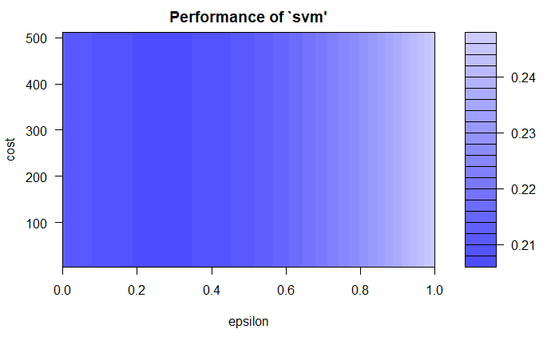

```r
plot(tuneResult_smoke)
```

```r
tuneResult <- tune(svm,smoker~.,data = train_smoke,ranges = list(epsilon = seq(0,0.3,0.01), cost = 2^(2:9)))
print(tuneResult)
```

```
Parameter tuning of svm:

- sampling method: 10-fold cross validation

- best parameters:
 epsilon cost
    0.27    4

- best performance: 0.2060867
```

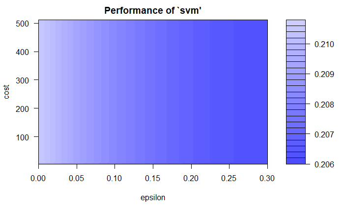

```r
plot(tuneResult)
```

```r
#tuned_svm
tuned_svm <- svm(smoker~.,train_smoke, epsilon = 0.25, cost = 4)
pred_tune_svm <- predict(tuned_svm,train_smoke)
rmse_tuned_svm <- RMSE(pred_tune_svm, train_smoke$smoker)
print(paste("svm_train_rmse: ",rmse_tuned_svm))
```

```
[1] "svm_train_rmse:  0.119748655502819"
```

```r
pred_tune_test <- predict(tuned_svm,test_smoke)
rmse_test_tuned_svm <- RMSE(pred_tune_test,test_smoke$smoker)
print(paste("svm_test_rmse: ",rmse_test_tuned_svm))
```

```
[1] "svm_test_rmse:  0.433616991884923"
```

# Smoker prediction models comparision

[output not shown]